# Лабораторная работа №4

Операционные системы

Закиров Н.Д., НКАбд-03-23

Российский университет дружбы народов, Москва, Россия

26 февраля 2024

# Информация

## Докладчик

- Закиров Нурислам Дамирович
- Студент 1 курса
- Группа: НКАбд-03-23
- Российский университет дружбы народов

# Лабораторная работа

## Цель работы

Целью данной лаболаторной работы является изучение идеологии и применение средств контроля версий и приобретение знаний по работе с git.

# Задание

- Заргеистрироваться на GitHub
- Создать базовую конфигурацию для работы с git
- Создать ключ SSH
- Создать ключ GPG
- Настроить подписи Git
- Создать локальный каталог для выполнения заданий по предмету.

## Установка программного обеспечения

Заранее регистрация в git уже была успешно выполнена, поэтому сразу переходим к следующим этапам. Устанавливаем git при помощи dnf install git и устанавливаем gh при помощи dnf install gh(рис. 1).

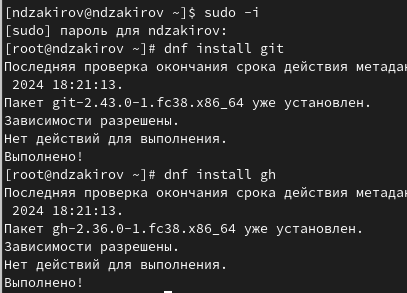

Установка git и gh

## Базовая настройка git

Далее настраиваем верификацию и подписание коммитов git, зададаем имя начальной ветки master, параметр autocrlf и safecrlf(рис. 2).

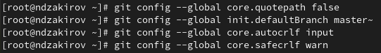

Базовая настройка git

## Создание ключа SSH

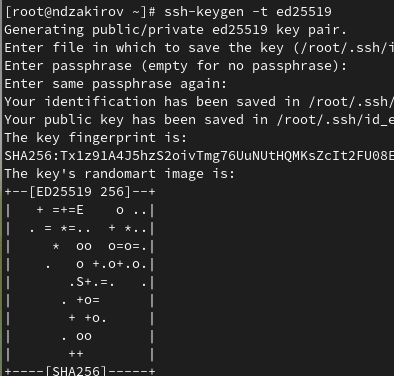

Создание ключа SSH

## Создание ключа GPG

Следующим этапом мы генерируем ключ pgp выбирая слудеющие опции:тип RSA and RSA, размер 4096, срок действия неограниченный (рис. 4).

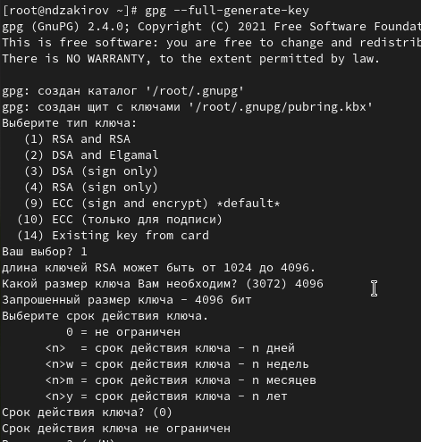

Создание ключа pgp

## Создание ключа GPG

После чего, мы копируем данный нам ключ командой gpg –armor –export | xclip -sel clip в буфер обмена, где вместо “PGP Fingerprint” вставляем данные занчения.(рис. 5).

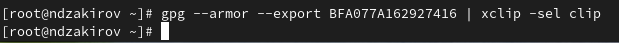

Копирование ключа в буфер обмена

## Создание ключа GPG

Теперь вставляем данный ключ при помощи комбинации Ctrl+V на официальном сайте GitHub в настройках GitHub, нажав на кнопку New GPG key(рис. 6).

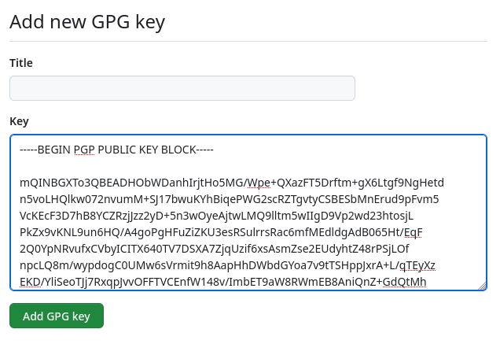

Окно New GPG key в GitHub

## Создание ключа GPG

Ключ успешно привязался(рис. 7).

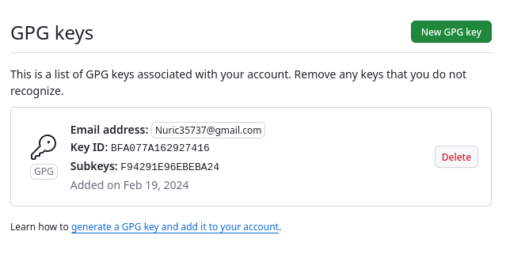

Окно GitHub

## Настройка подписи Git

Cледующим этапом мы используем введёный email и указываем Git применять его при подписи коммитов (рис. 8).

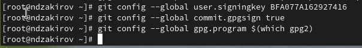

Настройка подписей коммитов git

## Настройка gh

Даллее мы авторизируемся в терминале через команду gh auth login. Отвечаем на все наводящие вопросы(рис. 9).

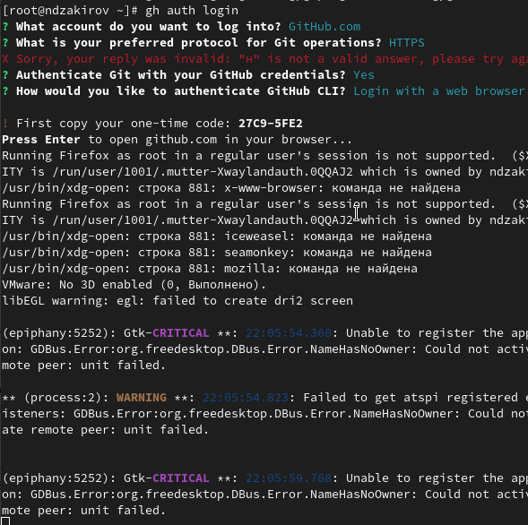

Авторизация gh

## Настройка gh

После входим в свой аккаунт GitHub через браузер(рис. 10).

[figure not shown]

Авторизация через браузер

## Настройка gh

После авторизации, Git просит ввести код, который мы заранее скопировали с терминала и вставили бразуре, после чего мы успешно авторизовались(рис. 11).

[figure not shown]

Успешная авторизация

## Настройка gh

В терминале также подтвержается наша авторизация(рис. 12).

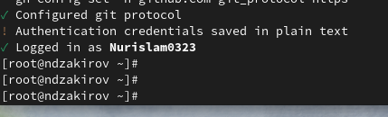

Успешная авторизация

## Создание шаблона для рабочего пространства

Далее нам необходимо создать шаблон рабочего пространства. При промощи mkdir -p ~/work/study/2023-2024/“Операционные системы” мы создаем каталог, после чего переходим в нее. Создаем шаблон при помощи gh repo create(рис. 13).

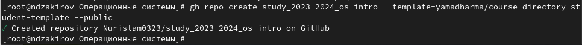

Создание репозитории курса

## Создание шаблона для рабочего пространства

После чего мы клониуем репозиторий курса на нашу систему при помощи git clone(рис. 14).

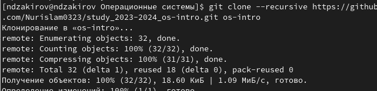

Создание репозитории курса

## Настройка каталога курса

Переходим в созданную папку os-intro при помощи cd(рис. 15).

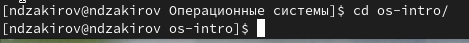

Перемещение по каталогам

## Настройка каталога курса

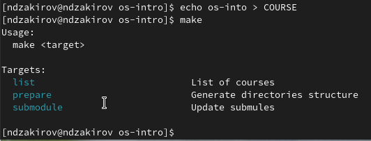

## Настройка каталога курса

Отправляем файлы на сервер GitHub при помощи git add, git commit и git push(рис. 18).

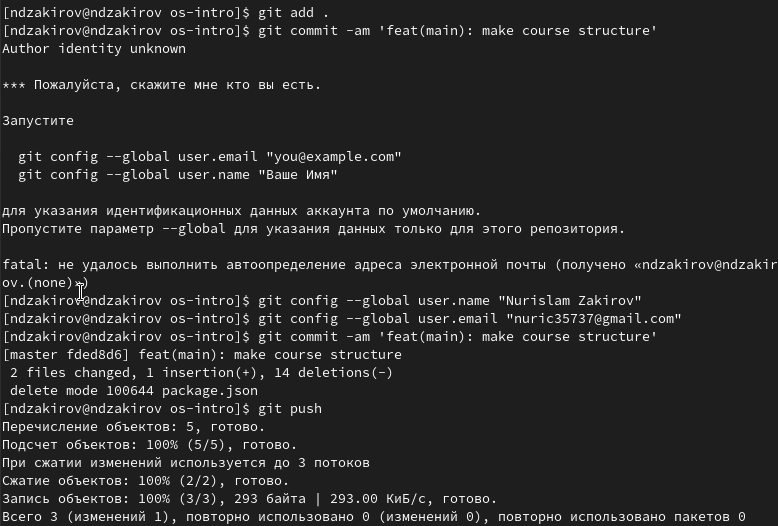

Отправка файлов на сервер

## Вывод

В ходе данной лаболаторной работы я изучил идеологии и применения средств контроля версий, а также приобрел знания по работе с git.

# Список литературы

1. Лабораторная работа № 2 [Электронный ресурс] URL: https://esystem.rudn.ru/mod/page/view.php?id=970819